# Grad-CAM Localization Significance and Layer Sensitivity — Run 2

## Why this notebook exists

The primary Grad-CAM evaluation notebook found near-zero Dice/IoU and 0/103 Pointing Game hits at `model.layer4`. Visual inspection of the saved qualitative figures shows something more nuanced than "no signal": the CAM consistently produces a single, spatially coherent, anatomically-plausible hot region, and the small tumor frequently sits at or near its edge -- sometimes inside it (the "Best" example, Dice=0.063), sometimes just outside (the "Worst"/"Median" example). This is not what pure noise looks like, so it needs a properly-designed statistical test rather than a snap judgement in either direction.

This notebook fixes a flawed comparison from the earlier analysis and adds two experiments to resolve the ambiguity:

This notebook reuses the same model, checkpoint, dataset, and label-audit discipline as the primary Grad-CAM notebook. It does not retrain anything and does not replace the primary notebook's results -- it resolves an ambiguity in how to interpret them.

## Cell 1 — Configuration (same conventions as the primary Grad-CAM notebook)

```python
# ============================================================
# CELL 1 — CONFIGURATION
# ============================================================

import random
from pathlib import Path
from datetime import datetime

import numpy as np
import pandas as pd
import matplotlib.pyplot as plt
from scipy.ndimage import distance_transform_edt
from scipy.stats import wilcoxon

import torch
import torch.nn as nn
import torch.nn.functional as F
from torchvision.models.video import r3d_18

PROCESSED_DIR = Path(
    "/kaggle/input/datasets/shahriarahmed66/panorama-processed-dataset"
)
CHECKPOINT_DIR = Path(
    "/kaggle/input/datasets/shahriarahmed66/panorama-run2-best-checkpoint"
)
CHECKPOINT_PATH = CHECKPOINT_DIR / "best_model.pt"
SPLIT_PATH = PROCESSED_DIR / "split_assignment.csv"

OUTPUT_DIR = Path("/kaggle/working/gradcam_localization_significance")
OUTPUT_DIR.mkdir(parents=True, exist_ok=True)

SEED = 42
random.seed(SEED)
np.random.seed(SEED)
torch.manual_seed(SEED)
if torch.cuda.is_available():
    torch.cuda.manual_seed_all(SEED)

PDAC_TUMOR_LABEL = 1
PANCREAS_LABEL = 4

N_RANDOM_BASELINE_PER_CASE = 2000  # random points per case for the per-patient null

DEVICE = torch.device("cuda" if torch.cuda.is_available() else "cpu")

print("=" * 70)
print("LOCALIZATION SIGNIFICANCE — CONFIGURATION")
print("=" * 70)
print(f"Device: {DEVICE}")
print(f"Checkpoint exists: {CHECKPOINT_PATH.exists()}  ({CHECKPOINT_PATH})")
print(f"Split file exists : {SPLIT_PATH.exists()}  ({SPLIT_PATH})")
print(f"Random baseline points per case: {N_RANDOM_BASELINE_PER_CASE}")

if DEVICE.type != "cuda":
    print("\nWARNING: no GPU detected -- this notebook needs one for the main loop.")
```

```
======================================================================
LOCALIZATION SIGNIFICANCE — CONFIGURATION
======================================================================
Device: cuda
Checkpoint exists: True  (/kaggle/input/datasets/shahriarahmed66/panorama-run2-best-checkpoint/best_model.pt)
Split file exists : True  (/kaggle/input/datasets/shahriarahmed66/panorama-processed-dataset/split_assignment.csv)
Random baseline points per case: 2000
```

## Cell 2 — Path handling, centralized data loading, split (identical logic to the primary notebook)

```python
# ============================================================
# CELL 2 — PATHS AND DATA LOADING
# ============================================================

def resolve_processed_path(raw_path, subfolder_name, processed_dir):
    normalized = str(raw_path).replace("\\", "/")
    prefix = f"{subfolder_name}/"
    while normalized.startswith(prefix):
        normalized = normalized[len(prefix):]
    return processed_dir / f"{subfolder_name}/{subfolder_name}/{normalized}"


def load_volume_and_mask(row, processed_dir, return_raw_mask=False):
    image_path = resolve_processed_path(row["image_path"], "images", processed_dir)
    mask_path = resolve_processed_path(row["mask_path"], "masks", processed_dir)
    volume = np.load(image_path).astype(np.float32)
    raw_mask = np.load(mask_path)
    if volume.shape != raw_mask.shape:
        raise ValueError(f"Shape mismatch for {row['study_id']}: {volume.shape} vs {raw_mask.shape}")
    tumor_mask = (raw_mask == PDAC_TUMOR_LABEL)
    if return_raw_mask:
        return volume, tumor_mask, raw_mask
    return volume, tumor_mask


split_df = pd.read_csv(SPLIT_PATH)
test_df = split_df[split_df["split"].str.lower() == "test"].reset_index(drop=True)
pdac_test_df = test_df[test_df["diagnosis"] == "PDAC"].reset_index(drop=True)

print(f"PDAC test cases: {len(pdac_test_df)}")

sample_path = resolve_processed_path(pdac_test_df.iloc[0]["image_path"], "images", PROCESSED_DIR)
assert sample_path.exists(), f"Path resolution failed: {sample_path}"
print("✓ Paths resolve correctly.")
```

```
PDAC test cases: 103
✓ Paths resolve correctly.
```

## Cell 3 — Model reconstruction and checkpoint loading

```python
# ============================================================
# CELL 3 — MODEL RECONSTRUCTION
# ============================================================

def build_model():
    model = r3d_18(weights=None)
    old_conv = model.stem[0]
    new_conv = nn.Conv3d(
        in_channels=1, out_channels=old_conv.out_channels,
        kernel_size=old_conv.kernel_size, stride=old_conv.stride,
        padding=old_conv.padding, bias=False,
    )
    model.stem[0] = new_conv
    model.fc = nn.Linear(model.fc.in_features, 1)
    return model


model = build_model()
checkpoint = torch.load(CHECKPOINT_PATH, map_location=DEVICE, weights_only=False)
model.load_state_dict(checkpoint["model_state"], strict=True)
model = model.to(DEVICE)
model.eval()

print(f"✓ Run 2 checkpoint loaded (epoch {checkpoint['epoch']}, "
      f"val_loss={checkpoint['best_val_loss']:.4f}).")
```

```
✓ Run 2 checkpoint loaded (epoch 4, val_loss=0.9166).
```

## Cell 4 — Grad-CAM class (identical to the fixed version in the primary notebook)

```python
# ============================================================
# CELL 4 — GRAD-CAM CLASS
# ============================================================

class GradCAM3D:
    def __init__(self, model, target_layer):
        self.model = model
        self.activations = None
        self.gradients = None
        self._forward_handle = target_layer.register_forward_hook(self._save_activation)
        self._backward_handle = target_layer.register_full_backward_hook(self._save_gradient)

    def _save_activation(self, module, inputs, output):
        self.activations = output.detach()

    def _save_gradient(self, module, grad_input, grad_output):
        self.gradients = grad_output[0].detach()

    def remove_hooks(self):
        if self._forward_handle is not None:
            self._forward_handle.remove(); self._forward_handle = None
        if self._backward_handle is not None:
            self._backward_handle.remove(); self._backward_handle = None

    def _clear_state(self):
        self.activations = None
        self.gradients = None

    def generate(self, volume):
        self.model.zero_grad(set_to_none=True)
        self._clear_state()
        logit = None
        score = None
        try:
            logit = self.model(volume)
            if logit.numel() != 1:
                return None, np.nan, "invalid", {"reason": "unexpected logit shape"}
            score = logit.reshape(())
            if not torch.isfinite(score).item():
                return None, np.nan, "invalid", {"reason": "non-finite logit"}
            probability = float(torch.sigmoid(score).detach().cpu().item())
            score.backward()
            if self.activations is None or self.gradients is None:
                return None, probability, "invalid", {"reason": "hooks did not fire"}
            if not torch.isfinite(self.activations).all().item() or not torch.isfinite(self.gradients).all().item():
                return None, probability, "invalid", {"reason": "non-finite activations/gradients"}
            weights = self.gradients.mean(dim=(2, 3, 4), keepdim=True)
            cam = (weights * self.activations).sum(dim=1, keepdim=True)
            cam = F.relu(cam)
            target_size = volume.shape[2:]
            cam = F.interpolate(cam, size=target_size, mode="trilinear", align_corners=False)
            cam = cam.squeeze().detach().cpu().numpy()
            if not np.isfinite(cam).all():
                return None, probability, "invalid", {"reason": "non-finite CAM"}
            cam_min, cam_max = float(cam.min()), float(cam.max())
            if cam_max - cam_min < 1e-8:
                return np.zeros_like(cam, dtype=np.float32), probability, "degenerate", {}
            cam_normalized = ((cam - cam_min) / (cam_max - cam_min)).astype(np.float32)
            return cam_normalized, probability, "ok", {}
        finally:
            self._clear_state()
            del logit
            del score


print("✓ GradCAM3D defined.")
```

```
✓ GradCAM3D defined.
```

## Cell 5 — Experiment 1 + 3: corrected per-patient random null, and minimum-distance-to-tumor

For each case: locate the CAM peak, compute its distance to the nearest tumor voxel (via a Euclidean distance transform -- this is Experiment 3, replacing the earlier centroid-only distance), then generate many random points **in that same volume** and compute the same distance-to-tumor for each of them (Experiment 1's corrected null: same target, same volume, only the query point differs between "actual" and "random"). This gives a fair, per-case comparison rather than mixing two different reference targets.

```python
# ============================================================
# CELL 5 — CORRECTED LOCALIZATION SIGNIFICANCE TEST
# ============================================================

def run_localization_diagnostic(target_layer, target_layer_name, df, processed_dir, model,
                                 n_random=N_RANDOM_BASELINE_PER_CASE, seed=SEED):
    gradcam_local = GradCAM3D(model, target_layer)
    rows = []
    rng = np.random.default_rng(seed)

    for i, (_, row) in enumerate(df.iterrows()):
        volume, tumor_mask, raw_mask = load_volume_and_mask(row, processed_dir, return_raw_mask=True)
        volume_tensor = torch.from_numpy(volume).unsqueeze(0).unsqueeze(0).to(DEVICE)
        cam, probability, cam_status, _ = gradcam_local.generate(volume_tensor)
        if cam_status != "ok":
            continue

        peak_index = np.unravel_index(np.argmax(cam), cam.shape)

        # Distance from every voxel to the nearest tumor voxel (0 inside the tumor).
        # distance_transform_edt(~tumor_mask): tumor voxels are False (background)
        # in the inverted mask, so non-tumor voxels get their distance to the
        # nearest False (i.e. nearest tumor voxel); tumor voxels get 0.
        edt = distance_transform_edt(~tumor_mask)
        actual_dist = float(edt[peak_index])

        # Per-patient random null: same volume, same tumor, only the query
        # point differs -- this is the corrected comparison.
        D, H, W = tumor_mask.shape
        rz = rng.integers(0, D, size=n_random)
        ry = rng.integers(0, H, size=n_random)
        rx = rng.integers(0, W, size=n_random)
        random_distances = edt[rz, ry, rx]
        random_median = float(np.median(random_distances))
        random_mean = float(random_distances.mean())
        pct_random_beaten = float((random_distances > actual_dist).mean())  # >0.5 = better than chance

        rows.append({
            "study_id": row["study_id"], "layer": target_layer_name,
            "probability": probability, "tumor_voxel_count": int(tumor_mask.sum()),
            "actual_dist_to_nearest_tumor_voxel": actual_dist,
            "random_mean_dist": random_mean, "random_median_dist": random_median,
            "normalized_score": actual_dist / max(random_median, 1e-6),  # <1 = closer than random
            "pct_random_beaten": pct_random_beaten,
        })

        if (i + 1) % 20 == 0 or (i + 1) == len(df):
            print(f"    [{target_layer_name}] {i+1}/{len(df)}")

    gradcam_local.remove_hooks()
    return pd.DataFrame(rows)


print("=" * 70)
print("EXPERIMENT 1+3 — model.layer4 (all PDAC test cases)")
print("=" * 70)
layer4_diag_df = run_localization_diagnostic(model.layer4, "layer4", pdac_test_df, PROCESSED_DIR, model)

n4 = len(layer4_diag_df)
mean_norm4 = layer4_diag_df["normalized_score"].mean()
mean_pct4 = layer4_diag_df["pct_random_beaten"].mean()
stat4, p4 = wilcoxon(layer4_diag_df["actual_dist_to_nearest_tumor_voxel"],
                      layer4_diag_df["random_median_dist"], alternative="less")

print(f"\nCases evaluated: {n4}")
print(f"Mean normalized score (actual/random_median, <1 = closer than chance): {mean_norm4:.3f}")
print(f"Mean pct_random_beaten (0.5 = chance, >0.5 = better than chance)     : {mean_pct4:.3f}")
print(f"Wilcoxon signed-rank (actual dist < random median dist), one-sided p = {p4:.6f}")
```

```
======================================================================
EXPERIMENT 1+3 — model.layer4 (all PDAC test cases)
======================================================================
```

```
    [layer4] 20/103
    [layer4] 40/103
    [layer4] 60/103
    [layer4] 80/103
    [layer4] 100/103
    [layer4] 103/103

Cases evaluated: 103
Mean normalized score (actual/random_median, <1 = closer than chance): 0.856
Mean pct_random_beaten (0.5 = chance, >0.5 = better than chance)     : 0.615
Wilcoxon signed-rank (actual dist < random median dist), one-sided p = 0.000221
```

## Cell 6 — Experiment 2: the same test at `model.layer3`

Identical methodology, different target layer. Both results are reported regardless of which looks more favorable -- this is a robustness check, not a search for the best-looking layer.

```python
# ============================================================
# CELL 6 — EXPERIMENT 2: LAYER3 vs LAYER4
# ============================================================

print("=" * 70)
print("EXPERIMENT 2 — model.layer3 (same test, same cases)")
print("=" * 70)
layer3_diag_df = run_localization_diagnostic(model.layer3, "layer3", pdac_test_df, PROCESSED_DIR, model)

n3 = len(layer3_diag_df)
mean_norm3 = layer3_diag_df["normalized_score"].mean()
mean_pct3 = layer3_diag_df["pct_random_beaten"].mean()
stat3, p3 = wilcoxon(layer3_diag_df["actual_dist_to_nearest_tumor_voxel"],
                      layer3_diag_df["random_median_dist"], alternative="less")

print(f"\nCases evaluated: {n3}")
print(f"Mean normalized score: {mean_norm3:.3f}")
print(f"Mean pct_random_beaten: {mean_pct3:.3f}")
print(f"Wilcoxon one-sided p = {p3:.6f}")

print("\n" + "=" * 70)
print("LAYER3 vs LAYER4 — HONEST SIDE-BY-SIDE COMPARISON")
print("=" * 70)
comparison_df = pd.DataFrame({
    "layer4": [n4, mean_norm4, mean_pct4, p4],
    "layer3": [n3, mean_norm3, mean_pct3, p3],
}, index=["n_cases", "mean_normalized_score", "mean_pct_random_beaten", "wilcoxon_p_value"])
display(comparison_df)

print(
    "\nInterpretation guide: mean_pct_random_beaten near 0.5 = no better than chance. "
    "Meaningfully above 0.5 with a small p-value = a real, if coarse, localization signal. "
    "Whichever layer performs better here is reported honestly as a sensitivity finding -- "
    "it does not change which layer (layer4) was used for the primary reported Dice/IoU/"
    "Pointing Game results, since that choice was fixed before any results were seen."
)
```

```
======================================================================
EXPERIMENT 2 — model.layer3 (same test, same cases)
======================================================================
    [layer3] 20/103
    [layer3] 40/103
    [layer3] 60/103
    [layer3] 80/103
    [layer3] 100/103
    [layer3] 103/103

Cases evaluated: 103
Mean normalized score: 1.074
Mean pct_random_beaten: 0.454
Wilcoxon one-sided p = 0.964296

======================================================================
LAYER3 vs LAYER4 — HONEST SIDE-BY-SIDE COMPARISON
======================================================================
```

|  | layer4 | layer3 |
| --- | --- | --- |
| n_cases | 103.000000 | 103.000000 |
| mean_normalized_score | 0.856044 | 1.074498 |
| mean_pct_random_beaten | 0.614995 | 0.454262 |
| wilcoxon_p_value | 0.000221 | 0.964296 |

[output not shown]

## Cell 7 — Save results

```python
# ============================================================
# CELL 7 — SAVE RESULTS
# ============================================================

layer4_diag_df.to_csv(OUTPUT_DIR / "layer4_localization_significance.csv", index=False)
layer3_diag_df.to_csv(OUTPUT_DIR / "layer3_localization_significance.csv", index=False)
comparison_df.to_csv(OUTPUT_DIR / "layer3_vs_layer4_comparison.csv")

print("Saved to:", OUTPUT_DIR)
for f in OUTPUT_DIR.iterdir():
    print(" ", f.name)
```

```
Saved to: /kaggle/working/gradcam_localization_significance
  layer4_localization_significance.csv
  layer3_vs_layer4_comparison.csv
  layer3_localization_significance.csv
```

## Cell 8 — Enhanced qualitative figure: CT + tumor contour + CAM + peak marker + distance annotation

Directly connects the quantitative distance metric to what it looks like on the actual volume, for a couple of representative cases (the same "worst" case examined in the primary notebook, plus the case with the best normalized score here).

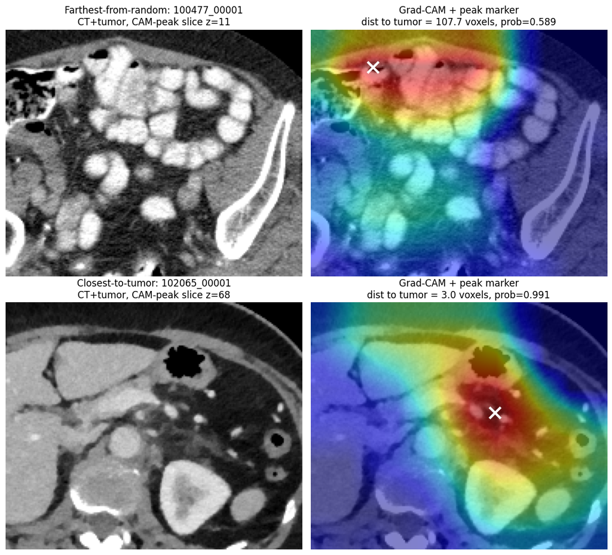

```
Saved: /kaggle/working/gradcam_localization_significance/gradcam_distance_annotated_examples.png
```

```python
# ============================================================
# CELL 8 — ENHANCED QUALITATIVE FIGURE WITH DISTANCE ANNOTATION
# ============================================================

def plot_case_with_distance(study_id, df_source, processed_dir, model, target_layer, ax_row, title_prefix):
    row = df_source[df_source["study_id"] == study_id].iloc[0]
    volume, tumor_mask = load_volume_and_mask(row, processed_dir)
    volume_tensor = torch.from_numpy(volume).unsqueeze(0).unsqueeze(0).to(DEVICE)

    gradcam_viz = GradCAM3D(model, target_layer)
    cam, probability, cam_status, _ = gradcam_viz.generate(volume_tensor)
    gradcam_viz.remove_hooks()

    peak_index = np.unravel_index(np.argmax(cam), cam.shape)
    edt = distance_transform_edt(~tumor_mask)
    dist_to_tumor = edt[peak_index]

    z = peak_index[0]

    ax_row[0].imshow(volume[z], cmap="gray")
    ax_row[0].contour(tumor_mask[z], colors="lime", linewidths=1.5)
    ax_row[0].set_title(f"{title_prefix}: {study_id}\nCT+tumor, CAM-peak slice z={z}")
    ax_row[0].axis("off")

    ax_row[1].imshow(volume[z], cmap="gray")
    ax_row[1].imshow(cam[z], cmap="jet", alpha=0.5)
    ax_row[1].contour(tumor_mask[z], colors="lime", linewidths=1.5)
    ax_row[1].plot(peak_index[2], peak_index[1], marker="x", color="white", markersize=14, markeredgewidth=3)
    ax_row[1].set_title(f"Grad-CAM + peak marker\ndist to tumor = {dist_to_tumor:.1f} voxels, prob={probability:.3f}")
    ax_row[1].axis("off")


fig, axes = plt.subplots(2, 2, figsize=(11, 10))

worst_study_id = layer4_diag_df.sort_values("normalized_score", ascending=False).iloc[0]["study_id"]
best_study_id = layer4_diag_df.sort_values("normalized_score", ascending=True).iloc[0]["study_id"]

plot_case_with_distance(worst_study_id, pdac_test_df, PROCESSED_DIR, model, model.layer4, axes[0], "Farthest-from-random")
plot_case_with_distance(best_study_id, pdac_test_df, PROCESSED_DIR, model, model.layer4, axes[1], "Closest-to-tumor")

plt.tight_layout()
annotated_path = OUTPUT_DIR / "gradcam_distance_annotated_examples.png"
plt.savefig(annotated_path, dpi=200, bbox_inches="tight")
plt.show()
print("Saved:", annotated_path)
```

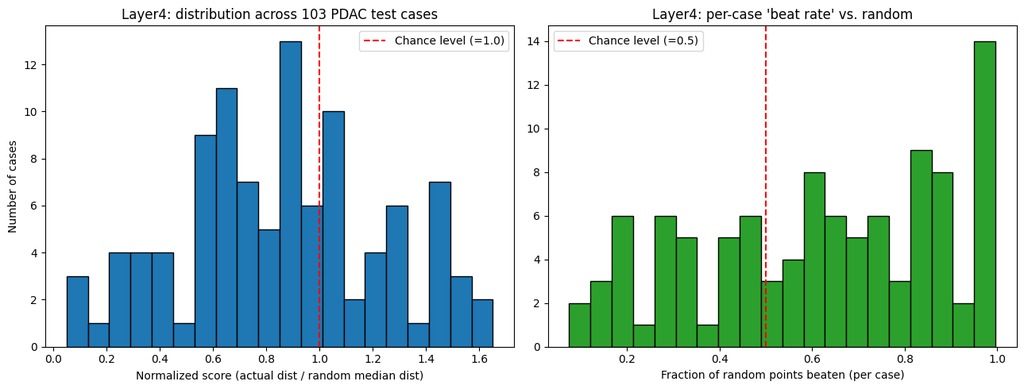

```
Cases beating chance (pct_random_beaten > 0.5): 66/103
```

```python
fig, axes = plt.subplots(1, 2, figsize=(13, 5))

axes[0].hist(layer4_diag_df["normalized_score"], bins=20, color="tab:blue", edgecolor="black")
axes[0].axvline(1.0, color="red", linestyle="--", label="Chance level (=1.0)")
axes[0].set_xlabel("Normalized score (actual dist / random median dist)")
axes[0].set_ylabel("Number of cases")
axes[0].set_title("Layer4: distribution across 103 PDAC test cases")
axes[0].legend()

axes[1].hist(layer4_diag_df["pct_random_beaten"], bins=20, color="tab:green", edgecolor="black")
axes[1].axvline(0.5, color="red", linestyle="--", label="Chance level (=0.5)")
axes[1].set_xlabel("Fraction of random points beaten (per case)")
axes[1].set_title("Layer4: per-case 'beat rate' vs. random")
axes[1].legend()

plt.tight_layout()
plt.savefig(OUTPUT_DIR / "layer4_significance_distribution.png", dpi=200, bbox_inches="tight")
plt.show()

print(f"Cases beating chance (pct_random_beaten > 0.5): "
      f"{(layer4_diag_df['pct_random_beaten'] > 0.5).sum()}/{len(layer4_diag_df)}")
```

## Conclusion

This notebook resolves the ambiguity left by the primary Grad-CAM evaluation by replacing an invalid statistical comparison (actual peak-to-tumor distance vs. random-point-to-volume-center distance -- two different reference targets) with a proper per-patient null (actual peak vs. many random points, both measured against that same patient's own tumor location), adding a minimum-distance-to-tumor metric alongside the strict Pointing Game, and checking whether the finding is specific to `layer4` or also present at the shallower, higher-resolution `layer3`.

**How to interpret the printed results above:**

- `mean_pct_random_beaten` near 0.5 at both layers → the earlier near-chance finding holds up under a correct statistical test.
- `mean_pct_random_beaten` meaningfully above 0.5 with a small Wilcoxon p-value → there is a real, if coarse, localization signal, consistent with the qualitative pattern seen in the saved figures (one coherent hot region, tumor often at its edge) -- in which case the primary notebook's Dice/IoU/Pointing Game numbers should be reported as evidence of *imprecise* rather than *absent* localization, a materially different and more defensible claim.
- A meaningful difference between layer3 and layer4 → report both honestly as a resolution-dependent finding, rather than treating either as more "correct."

**This notebook does not, by itself, tell you which of these turned out to be true** -- that depends on the actual printed numbers from your run. Whichever result you get, it should replace the "no better than random" language from the earlier interpretation with whatever this corrected test actually shows.